# Family Income and Expenditure in the Philippines

Patrik Sarabia

May 18, 2018

## Introduction

This is an EDA for Family Income and Expenditure in the Philippines. In order to use this data set, I wanted to see if it is possible to predict the total income of a family in the Philippines based on their expenditures.

The data comes from the following url: https://www.kaggle.com/grosvenpaul/family-income-and-expenditure

All of the analysis done with this data set is used in R. Before we begin, PHP is the currency for the Philippines and stands for Philippine peso.

## Preparation

First, load the relevant libraries that will be needed in the analysis.

```r
#Load relevant libraries
library(tidyverse)
library(tibble)
library(broom)
```

Next, read the data using the read_csv function

```r
##Read the data
data <- read_csv("Family Income and Expenditure.csv/Family Income and Expenditure.csv")

data
```

```
## # A tibble: 41,544 x 60
##    `Total Household Inc~ Region `Total Food Expendi~ `Main Source of Inco~
##                    <int> <chr>                 <int> <chr>
##  1                480332 CAR                  117848 Wage/Salaries
##  2                198235 CAR                   67766 Wage/Salaries
##  3                 82785 CAR                   61609 Wage/Salaries
##  4                107589 CAR                   78189 Wage/Salaries
##  5                189322 CAR                   94625 Wage/Salaries
##  6                152883 CAR                   73326 Wage/Salaries
##  7                198621 CAR                  104644 Wage/Salaries
##  8                134961 CAR                   95644 Other sources of Inc~
##  9                171152 CAR                   67348 Other sources of Inc~
## 10                625753 CAR                  158721 Enterpreneurial Acti~
## # ... with 41,534 more rows, and 56 more variables: `Agricultural
## #   Household indicator` <int>, `Bread and Cereals Expenditure` <int>,
## #   `Total Rice Expenditure` <int>, `Meat Expenditure` <int>, `Total Fish
## #   and marine products Expenditure` <int>, `Fruit Expenditure` <int>,
## #   `Vegetables Expenditure` <int>, `Restaurant and hotels
## #   Expenditure` <int>, `Alcoholic Beverages Expenditure` <int>, `Tobacco
## #   Expenditure` <int>, `Clothing, Footwear and Other Wear
## #   Expenditure` <int>, `Housing and water Expenditure` <int>, `Imputed
## #   House Rental Value` <int>, `Medical Care Expenditure` <int>,
## #   `Transportation Expenditure` <int>, `Communication Expenditure` <int>,
## #   `Education Expenditure` <int>, `Miscellaneous Goods and Services
## #   Expenditure` <int>, `Special Occasions Expenditure` <int>, `Crop
## #   Farming and Gardening expenses` <int>, `Total Income from
## #   Entrepreneurial Acitivites` <int>, `Household Head Sex` <chr>,
## #   `Household Head Age` <int>, `Household Head Marital Status` <chr>,
## #   `Household Head Highest Grade Completed` <chr>, `Household Head Job or
## #   Business Indicator` <chr>, `Household Head Occupation` <chr>,
## #   `Household Head Class of Worker` <chr>, `Type of Household` <chr>,
## #   `Total Number of Family members` <int>, `Members with age less than 5
## #   year old` <int>, `Members with age 5 - 17 years old` <int>, `Total
## #   number of family members employed` <int>, `Type of
## #   Building/House` <chr>, `Type of Roof` <chr>, `Type of Walls` <chr>,
## #   `House Floor Area` <int>, `House Age` <int>, `Number of
## #   bedrooms` <int>, `Tenure Status` <chr>, `Toilet Facilities` <chr>,
## #   Electricity <int>, `Main Source of Water Supply` <chr>, `Number of
## #   Television` <int>, `Number of CD/VCD/DVD` <int>, `Number of
## #   Component/Stereo set` <int>, `Number of Refrigerator/Freezer` <int>,
## #   `Number of Washing Machine` <int>, `Number of Airconditioner` <int>,
## #   `Number of Car, Jeep, Van` <int>, `Number of Landline/wireless
## #   telephones` <int>, `Number of Cellular phone` <int>, `Number of
## #   Personal Computer` <int>, `Number of Stove with Oven/Gas Range` <int>,
## #   `Number of Motorized Banca` <int>, `Number of
## #   Motorcycle/Tricycle` <int>
```

As you can see, this data set has a lot of column attributes, 60 columns, to be exact. Fortunately, not all of them are needed to perform the analysis. Using the select function will take out the irrelevant columns for the analysis. Using the colnames function allows to replace the column names so that it is easier to access the column names.

```r
##Select only the relevant columns
new_data <- data %>%
  select(1:2, 6:24, "Total Number of Family members")

##Rename the column names for the data
colnames(new_data) <- c("total_income", "region", "bread_expenses", "rice_expenses", "meat_expenses", "seafood_expenses", "fruit_expenses", "vegetable_expenses", "restaurant_expenses", "alcohol_expenses", "tobacco_expenses", "clothing_expenses", "housing_expenses", "house_value", "medical_expenses", "transportation_expenses", "communication_expenses", "education_expenses", "miscalleanous_expenses", "special_expenses", "farming_expenses", "family_members")

##Join miscallenaous_expenses and special_expenses and remove them
new_data <- new_data %>%
  mutate(miscalleanous_expenses = new_data$miscalleanous_expenses + new_data$special_expenses) %>%
  select(-special_expenses)

##Since we will be using a log transform for the plots, just add 1 to values with zeroes
new_data$bread_expenses[new_data$bread_expenses == 0] <- 1
new_data$rice_expenses[new_data$rice_expenses == 0] <- 1
new_data$meat_expenses[new_data$meat_expenses == 0] <- 1
new_data$seafood_expenses[new_data$seafood_expenses == 0] <- 1
new_data$fruit_expenses[new_data$fruit_expenses == 0] <- 1
new_data$vegetable_expenses[new_data$vegetable_expenses == 0] <- 1
new_data$restaurant_expenses[new_data$restaurant_expenses == 0] <- 1
new_data$alcohol_expenses[new_data$alcohol_expenses == 0] <- 1
new_data$tobacco_expenses[new_data$tobacco_expenses == 0] <- 1
new_data$clothing_expenses[new_data$clothing_expenses == 0] <- 1
new_data$housing_expenses[new_data$housing_expenses == 0] <- 1
new_data$house_value[new_data$house_value == 0] <- 1
new_data$medical_expenses[new_data$medical_expenses == 0] <- 1
new_data$transportation_expenses[new_data$transportation_expenses == 0] <- 1
new_data$communication_expenses[new_data$communication_expenses == 0] <- 1
new_data$education_expenses[new_data$education_expenses == 0] <- 1
new_data$miscalleanous_expenses[new_data$miscalleanous_expenses == 0] <- 1
new_data$farming_expenses[new_data$farming_expenses == 0] <- 1


new_data
```

```
## # A tibble: 41,544 x 21
##    total_income region bread_expenses rice_expenses meat_expenses
##           <int> <chr>           <dbl>         <dbl>         <dbl>
##  1       480332 CAR             42140         38300         24676
##  2       198235 CAR             17329         13008         17434
##  3        82785 CAR             34182         32001          7783
##  4       107589 CAR             34030         28659         10914
##  5       189322 CAR             34820         30167         18391
##  6       152883 CAR             29065         25190         15336
##  7       198621 CAR             40992         36312         12968
##  8       134961 CAR             37168         28156         14640
##  9       171152 CAR             23117         15845         11464
## 10       625753 CAR             56003         43239         26488
## # ... with 41,534 more rows, and 16 more variables:
## #   seafood_expenses <dbl>, fruit_expenses <dbl>,
## #   vegetable_expenses <dbl>, restaurant_expenses <dbl>,
## #   alcohol_expenses <dbl>, tobacco_expenses <dbl>,
## #   clothing_expenses <dbl>, housing_expenses <dbl>, house_value <dbl>,
## #   medical_expenses <dbl>, transportation_expenses <dbl>,
## #   communication_expenses <dbl>, education_expenses <dbl>,
## #   miscalleanous_expenses <dbl>, farming_expenses <dbl>,
## #   family_members <int>
```

The data set above will be the one that is used to perform the analysis.

## Visualization

From Wikipedia, the Philippines is the 34th largest economy of the world. With that being said, let us find the average household income, the average expenditure and the average savings for a family in the Philippines.

```r
new_data %>%
  mutate(total_expenses = bread_expenses + rice_expenses + meat_expenses + seafood_expenses + fruit_expenses + vegetable_expenses + restaurant_expenses + alcohol_expenses + tobacco_expenses + clothing_expenses + housing_expenses + house_value + medical_expenses + transportation_expenses + education_expenses + miscalleanous_expenses + farming_expenses) %>%
  mutate(savings = total_income - total_expenses) %>%
  summarize(mean_income = mean(total_income), mean_expenditure = mean(total_expenses), mean_savings = mean(savings))
```

```
## # A tibble: 1 x 3
##   mean_income mean_expenditure mean_savings
##         <dbl>            <dbl>        <dbl>
## 1      247556           213071        34484
```

From the data, the annual average household income, average expenditure, and average savings for a family in the Philippines is 247555.6 PHP, 213071.2 PHP, and 34484.41 PHP, respectively. In dollars, these figures translate to $4762.97, $4076.45, and $659.69, respectively.

Although these numbers give us the average income, expenses, and savings, it is better to look at the numbers for each region because some regions are rich like the NCR region, while some regions are poor like the ARMM region. This way, we can get a better look at the average income, expenses, and savings for a family in the Philippines. The code here is similar to the one above, except we make a call to group_by()

```r
filtered_data <- new_data %>%
  group_by(region) %>%
  mutate(total_expenses = bread_expenses + rice_expenses + meat_expenses + seafood_expenses + fruit_expenses + vegetable_expenses + restaurant_expenses + alcohol_expenses + tobacco_expenses + clothing_expenses + housing_expenses + house_value + medical_expenses + transportation_expenses + education_expenses + miscalleanous_expenses + farming_expenses) %>%
  mutate(savings = total_income - total_expenses) %>%
  select(c(total_income, region, total_expenses, savings))

filtered_data
```

```
## # A tibble: 41,544 x 4
## # Groups:   region [17]
##    total_income region total_expenses savings
##           <int> <chr>           <dbl>   <dbl>
##  1       480332 CAR            345011  135321
##  2       198235 CAR            207135 -  8900
##  3        82785 CAR            123466 - 40681
##  4       107589 CAR            151423 - 43834
##  5       189322 CAR            202821 - 13499
##  6       152883 CAR            131680   21203
##  7       198621 CAR            270797 - 72176
##  8       134961 CAR            239184 -104223
##  9       171152 CAR            112029   59123
## 10       625753 CAR            322077  303676
## # ... with 41,534 more rows
```

The data above shows the total expenses, total savings, total income and region based on the given household. Since it is a large data set, a boxplot for each region can see the average for each the attributes.

First, a boxplot between region and total income. Before we do the plot, a log transform will be used on the total income so that it is easier to visualize some of the data

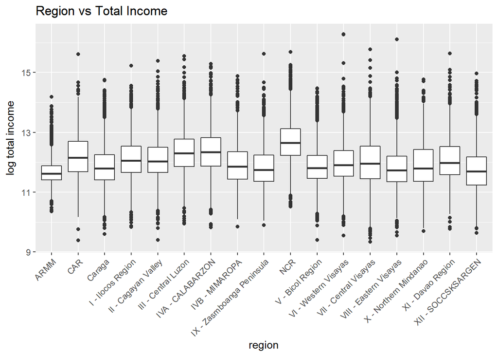

```r
filtered_data %>%
  ggplot(aes(x=region, y = log(total_income))) +
  geom_boxplot() +
  labs(title = "Region vs Total Income", x = "region", y = "log total income") +
  theme(axis.text.x = element_text(angle = 45, hjust = 1))
```

It is evident from the box plot above that the NCR region has the highest average total household income. While, the ARMM region has the lowest average total household income. To see these numbers, we can run the following code.

```r
filtered_data %>%
  group_by(region) %>%
  summarize(mean_income = mean(total_income))
```

```
## # A tibble: 17 x 2
##    region                    mean_income
##    <chr>                           <dbl>
##  1 ARMM                           134747
##  2 CAR                            269540
##  3 Caraga                         196907
##  4 I - Ilocos Region              238110
##  5 II - Cagayan Valley            236778
##  6 III - Central Luzon            292965
##  7 IVA - CALABARZON               303361
##  8 IVB - MIMAROPA                 216685
##  9 IX - Zasmboanga Peninsula      191001
## 10 NCR                            420862
## 11 V - Bicol Region               186105
## 12 VI - Western Visayas           220481
## 13 VII - Central Visayas          234909
## 14 VIII - Eastern Visayas         196737
## 15 X - Northern Mindanao          214058
## 16 XI - Davao Region              238116
## 17 XII - SOCCSKSARGEN             182985
```

From the data above, families in the NCR, on average, has a household income of 420,861.9 PHP anually, which is about $8051.09/ year. While, familes in the ARMM region, on average, has a household income of 134,746.8 PHP anually, which is about $2577.71/year. From the box plot above and data frame above, it implies that total income has a dependancy on region.

Next, let us see if total income depends on the total expenses for a given household. Just like the analysis for total income above, the process is also similar.

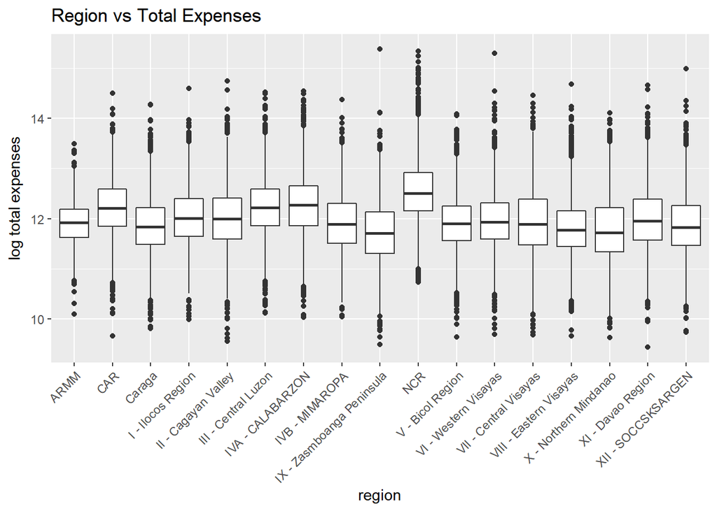

```r
filtered_data %>%
  ggplot(aes(x=region, y = log(total_expenses))) +
  geom_boxplot() +
  labs(title = "Region vs Total Expenses", x = "region", y = "log total expenses") +
  theme(axis.text.x = element_text(angle = 45, hjust = 1))
```

```r
filtered_data %>%
  group_by(region) %>%
  summarize(mean_expenses = mean(total_expenses))
```

```
## # A tibble: 17 x 2
##    region                    mean_expenses
##    <chr>                             <dbl>
##  1 ARMM                             161056
##  2 CAR                              242612
##  3 Caraga                           174943
##  4 I - Ilocos Region                195944
##  5 II - Cagayan Valley              203478
##  6 III - Central Luzon              243186
##  7 IVA - CALABARZON                 255630
##  8 IVB - MIMAROPA                   184027
##  9 IX - Zasmboanga Peninsula        155036
## 10 NCR                              346055
## 11 V - Bicol Region                 175965
## 12 VI - Western Visayas             189431
## 13 VII - Central Visayas            197741
## 14 VIII - Eastern Visayas           169783
## 15 X - Northern Mindanao            169558
## 16 XI - Davao Region                200033
## 17 XII - SOCCSKSARGEN               177666
```

Just like total income, NCR has the highest average total expenses anually, 346,055.2 PHP or about $6,620.04. However, the Zasmboanga Peninsula has the lowest total expeses anually, 155,036.1 PHP or $2,965.80. The plot and data frame also implies that total expenses has an influence on the total income for a given household.

So far, we have only observed plots between expenditure and income based on region. In the data set, there is one more attribute that has not been analyze. That is, the number of family members. In other words, does the number of family members have an influence on the total income for a given household? Just like the two plots above, we can also use a boxplot, however we group by the number of family members, instead of region.

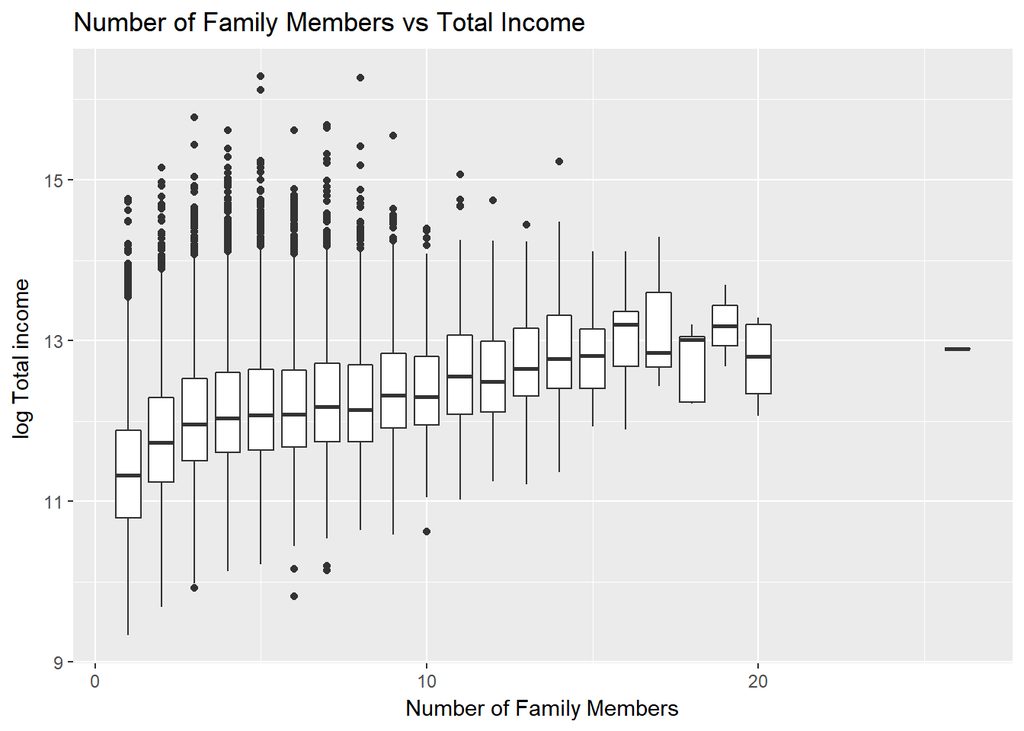

```r
new_data %>%
  ggplot(aes(x=family_members, y=log(total_income), group=family_members)) +
  geom_boxplot() +
  labs(title = "Number of Family Members vs Total Income", x = "Number of Family Members", y = "log Total income ")
```

From the plot above, as the number of family members increase, the average total household income increases. This implies that there is correlation between number of family members and total income. So, we can most likely use number of family members in our regression model.

From the three plots above, it is evident that our attributes our can be used as a predictor for our regression model. Now, we can start on our regression.

## Regression

So, the column attributes might be good candidates to be in the regression model. A big problem for regression is that there can be multiple regressions and experiments must be made which regression model is better. For this section, there will be two regression models that will be looked at: a model where all the column attributes are used and a model where attributes are cut down by creating new attributes based on the old ones.

Before the regression model is created, only 10% of the data is used to evaluate the performace of the model. The function sample_frac() can get a subset of the data and group_by region was also used so that each region has a representative sample.

```r
#set seed so that same data is obtained for each run
set.seed(1234)
#Take 10% of the data
subset_df <- new_data %>%
  group_by(region) %>%
  sample_frac(.1)
```

Now that subset of the data is obtained, the lm function is used to create the regression model. Using the tidy function on the lmfit let us analyze the model a bit better.

```r
#Use the lm function to create the model
lmfit <- lm(total_income~., data=subset_df)

tidy(lmfit) %>% slice(c(10, 18, 36))
```

```
## # A tibble: 3 x 5
##   term            estimate std.error statistic p.value
##   <chr>              <dbl>     <dbl>     <dbl>   <dbl>
## 1 regionNCR      -13447    20150        -0.667  0.505
## 2 bread_expenses      1.35     0.698     1.93   0.0538
## 3 family_members   1072     1968         0.545  0.586
```

Now that the model is created, one can see the performance by evaluating creating a violin plot for the residue created by the model.

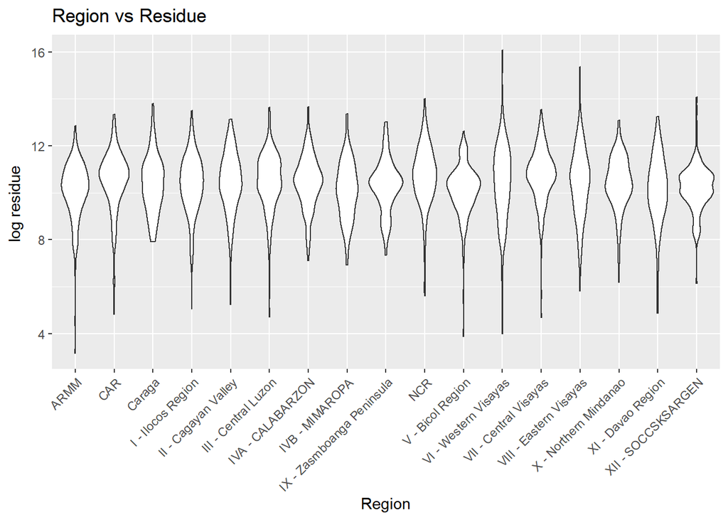

```r
augment_data <- augment(lmfit)

#Convert negative residues into positive
augment_data$.resid[augment_data$.resid < 0] <- augment_data$.resid * (-1)

#Plot the residue for each region
augment_data %>%
  ggplot(aes(x=region, y=log(.resid))) +
  geom_violin() +
  labs(title = "Region vs Residue", x = "Region", y = "log residue ") +
  theme(axis.text.x = element_text(angle = 45, hjust = 1))
```

From the plot above, it looks like the residue for each region is about 22,026.47 PHP or $421.40. It is a very high residue. Another way to measure performace of linear regression model is to get the coefficient of determination.

```r
summary(lmfit)$r.squared
```

```
## [1] 0.623139
```

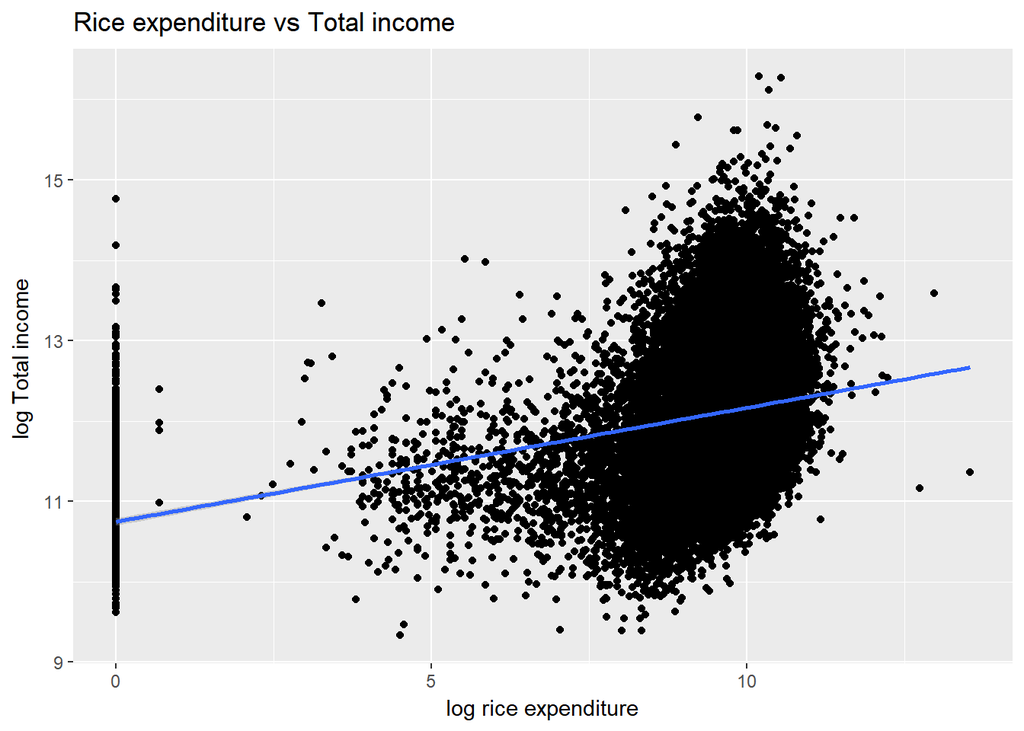

```r
new_data %>%
  ggplot(aes(x=log(rice_expenses), y=log(total_income))) +
  geom_point() +
  labs(title = "Rice expenditure vs Total income", x = "log rice expenditure", y = "log Total income ") +
  geom_smooth(method=lm)
```

With the problems of multiple regression with many predictors, is it possible to do better? That is, if the predictors for the model was cut down, will we get a lower residue? The only way to answer is to create the model.

So, for the second model, the same 10% of the data is used so that the same values are used. However, different sets of predictors will be used. In the Visualization part, there was a correlation between total expenses and total income, so this predictor should probably be used. But, it is also imperative that the model must not have a small set of predictors such that it will give bad predictions. So, the total expenses will broken up based on food, entertainment, and necessities.

```r
new_sub_df <- subset_df %>%
  #Get all the food expenses
  mutate(food_expenses = bread_expenses + rice_expenses + meat_expenses + seafood_expenses + fruit_expenses + vegetable_expenses) %>%
  #Get all the entertainment expenses
  mutate(entertainment_expenses = restaurant_expenses + alcohol_expenses + tobacco_expenses + miscalleanous_expenses) %>%
  #Get all the necessary expenses
  mutate(neccesary_expenses = clothing_expenses + housing_expenses + house_value + medical_expenses + transportation_expenses + communication_expenses + education_expenses + farming_expenses) %>%
  select(c("total_income", "region", "food_expenses", "entertainment_expenses", "neccesary_expenses", "family_members"))

new_sub_df
```

```
## # A tibble: 4,155 x 6
## # Groups:   region [17]
##    total_income region food_expenses entertainment_expe~ neccesary_expens~
##           <int> <chr>          <dbl>               <dbl>             <dbl>
##  1        73435 ARMM           54671                3667             17056
##  2        70630 ARMM           84176                7154             39606
##  3       144263 ARMM          114356                9147             91331
##  4        80146 ARMM           36693               15941             26021
##  5        94550 ARMM           64943                7404             21843
##  6       108240 ARMM           51957               30026             66641
##  7       115930 ARMM           63138               25972             22686
##  8        97579 ARMM           52024                4569             28489
##  9        98045 ARMM           52265               16815            117649
## 10        88405 ARMM           52791                9822             35442
## # ... with 4,145 more rows, and 1 more variable: family_members <int>
```

The data frame above still has total income, region, and number of family members as the columns. However, there are three new columns: food_expenses, entertainment_expenses, and necessary expenses. The code above explains which columns from the old data set was added to create the new columns.

Now that the second data frame, use the lm function to create a regression model.

```r
lmfit2 <- lm(total_income~., data=new_sub_df)

tidy(lmfit2) %>% slice(c(10, 18:21))
```

```
## # A tibble: 5 x 5
##   term                    estimate  std.error statistic            p.value
##   <chr>                      <dbl>      <dbl>     <dbl>              <dbl>
## 1 regionNCR              -34575    19580         - 1.77          7.75e-  2
## 2 food_expenses               1.41     0.141      10.0           2.79e- 23
## 3 entertainment_expenses      2.56     0.115      22.1           8.35e-103
## 4 neccesary_expenses          1.24     0.0327     37.9           1.85e-269
## 5 family_members         - 6724     1934         - 3.48          5.12e-  4
```

Now, graph the residue for the second model vs region

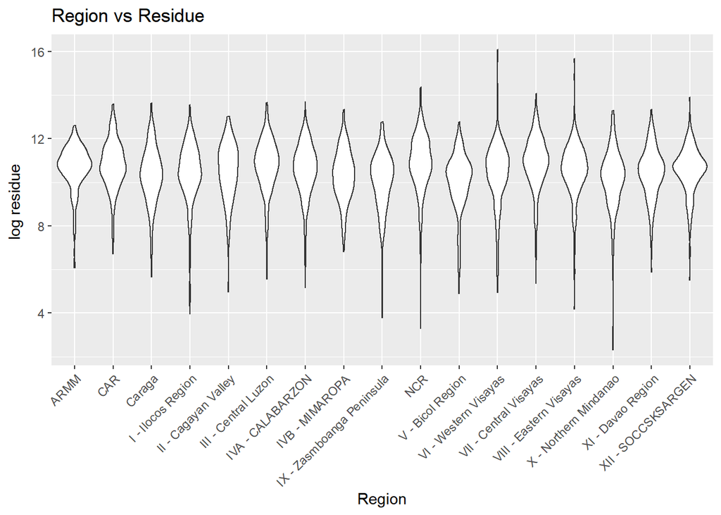

```r
augment_data2 <- augment(lmfit2)

augment_data2$.resid <- abs(augment_data2$.resid)

augment_data2 %>%
  ggplot(aes(x=region, y=log(.resid))) +
  geom_violin() +
  labs(title = "Region vs Residue", x = "Region", y = "log residue ") +
  theme(axis.text.x = element_text(angle = 45, hjust = 1))
```

From the plot above, it looks like the residue is about 22,026.47 PHP or $421.40. This residue is the same the first model. So, it looks like from the two plots there is no discernable difference. However, by computing the coefficient of determination, it will be evident which model is better.

```r
summary(lmfit2)$r.squared
```

```
## [1] 0.5784654
```

## Final Regression

With that in mind, the final model can be created for the whole data set.

```r
lmfitfinal <- lm(total_income~., data=new_data)

tidy(lmfitfinal) %>% slice(c(10, 18, 36))
```

```
## # A tibble: 3 x 5
##   term             estimate std.error statistic   p.value
##   <chr>               <dbl>     <dbl>     <dbl>     <dbl>
## 1 regionNCR      -10677      4473         -2.39 0.0170
## 2 bread_expenses      0.576     0.134      4.31 0.0000161
## 3 family_members    755       420          1.80 0.0725
```

The model can be validated by creating a scatter plot on fitted values vs residue. If the line through the plot is y = 0, then the model is a good fit.

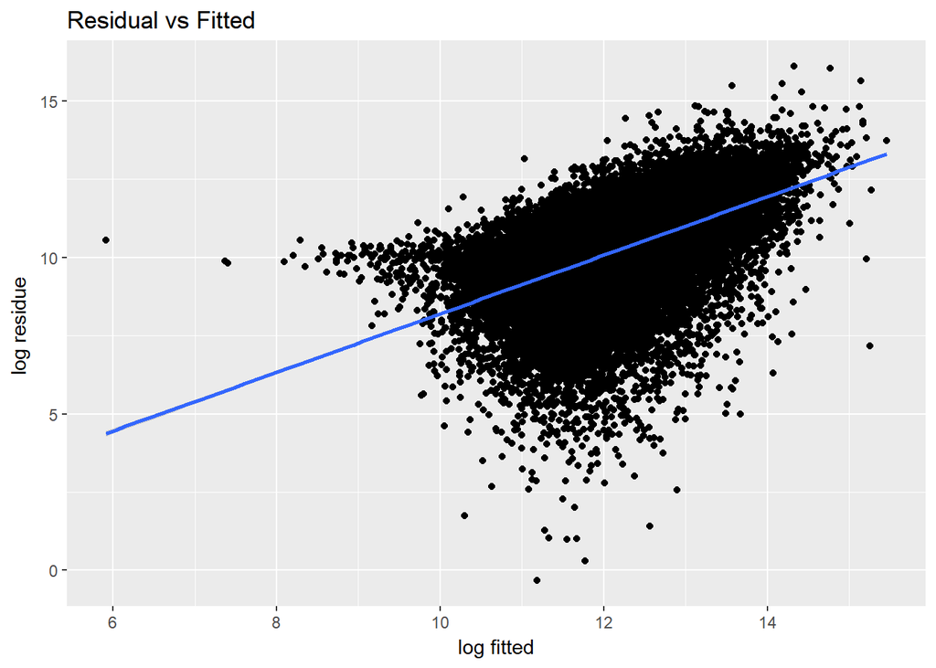

```r
augment_final <- augment(lmfitfinal)

augment_final$.resid <- abs(augment_final$.resid)

augment_final %>%
ggplot(aes(x = log(.fitted), y = log(.resid))) + geom_point() +
  geom_smooth(method=lm) +
   labs(title = "Residual vs Fitted", x = "log fitted", y = "log residue ")
```

The plot above shows that the line through the points is not y = 0, but an increasing line. This implies that the lower fitted values have lower error, while higher fitted values have higher error.

```r
summary(lmfitfinal)$r.squared
```

```
## [1] 0.7316433
```

## Conclusion

From this report, total household income was predicted based on several factors, such as the region where the family lives, meat expenditure, number of family members, and etc. Before creating the final model, two preliminary models were created based on 10% of the data. The model with the higher coefficient of determination was picked to be the best model to be created with the whole data. The final model ended up only explaining 73% of the whole data, while 27% of the data can be explained by several factors. The residue vs fitted values scatter plot also implied that a better model might be needed to describe the data. ##Resources kaggle.com wikipedia.com